# Spatial Species Accumulation: Aliens vs Natives in Austria

Gilles Colling & Liam

2026-01-28

# Setup

```r
library(spacc)
library(data.table)
library(ggplot2)

data_path <- "../data/"
```

# 1. Load and Prepare Data

```r
header  <- fread(file.path(data_path, "austria_header.csv"))
species <- fread(file.path(data_path, "austria_species.csv"))

cat(sprintf("Plots: %d\nSpecies records: %d\nUnique species: %d\n",
            nrow(header), nrow(species), uniqueN(species$WFO_TAXON)))
```

```
## Plots: 52526
## Species records: 852075
## Unique species: 2700
```

```r
species[, .N, by = STATUS]
```

```
##    STATUS      N
##    <char>  <int>
## 1: native 826055
## 2:    neo  26020
```

## Build species matrices

Split by native/alien status and create separate site-by-species matrices sharing the same row order. We also assign each plot to a decade for temporal analysis.

```r
rds_mats <- file.path(comp_dir, "matrices.rds")

# Keep only plots present in both header and species
common_ids <- intersect(header$PlotObservationID, species$PlotObservationID)
header <- header[PlotObservationID %in% common_ids]

# Assign decade
header[, decade := ifelse(Year < 1970, "pre-1970",
                          paste0(floor(Year / 10) * 10, "s"))]

# Coordinates
coords <- header[, .(x = Longitude, y = Latitude)]

# Helper: long-form species table -> wide presence/absence matrix
make_pa_matrix <- function(sp_data, plot_ids) {
  sp_data <- sp_data[PlotObservationID %in% plot_ids]
  wide <- dcast(sp_data, PlotObservationID ~ WFO_TAXON,
                fun.aggregate = function(x) as.integer(length(x) > 0),
                value.var = "WFO_TAXON")
  wide <- wide[match(plot_ids, PlotObservationID)]
  mat <- as.matrix(wide[, -1])
  mat[is.na(mat)] <- 0L
  rownames(mat) <- wide$PlotObservationID
  mat
}

if (file.exists(rds_mats)) {
  cat("Loading cached matrices...\n")
  mats <- readRDS(rds_mats)
  native_mat <- mats$native; alien_mat <- mats$alien; all_mat <- mats$all
  rm(mats)
} else {
  plot_ids <- header$PlotObservationID
  native_mat <- make_pa_matrix(species[STATUS == "native"], plot_ids)
  alien_mat  <- make_pa_matrix(species[STATUS == "neo"],    plot_ids)
  all_mat    <- make_pa_matrix(species, plot_ids)
  saveRDS(list(native = native_mat, alien = alien_mat, all = all_mat), rds_mats)
}

cat(sprintf("Native species: %d\nAlien species:  %d\nAll species:    %d\n",
            ncol(native_mat), ncol(alien_mat), ncol(all_mat)))
```

```
## Native species: 2378
## Alien species:  323
## All species:    2700
```

```r
# Decade summary
cat("\nPlots per decade:\n")
```

```
##
## Plots per decade:
```

```r
print(header[, .N, by = decade][order(decade)])
```

```
##      decade     N
##      <char> <int>
## 1:    1970s  2386
## 2:    1980s  3171
## 3:    1990s  8814
## 4:    2000s  4992
## 5:    2010s  8285
## 6:    2020s   104
## 7: pre-1970  2105
```

# 2. Temporal Accumulation Curves (per decade)

```r
decades <- sort(unique(header$decade))

rds_decade <- file.path(comp_dir, "decade_results.rds")
if (file.exists(rds_decade)) {
  cat("Loading cached decade results...\n")
  decade_results <- readRDS(rds_decade)
} else {
  decade_results <- lapply(decades, function(d) {
    idx <- which(header$decade == d)
    n <- length(idx)
    cat(sprintf("  %s: %d sites\n", d, n))
    spacc(all_mat[idx, , drop = FALSE], coords[idx, ],
          n_seeds = min(100, n), method = "knn",
          distance = "haversine", seed = 42)
  })
  names(decade_results) <- decades
  saveRDS(decade_results, rds_decade)
}
```

```
## Loading cached decade results...
```

```r
decade_combined <- do.call(c, decade_results)
```

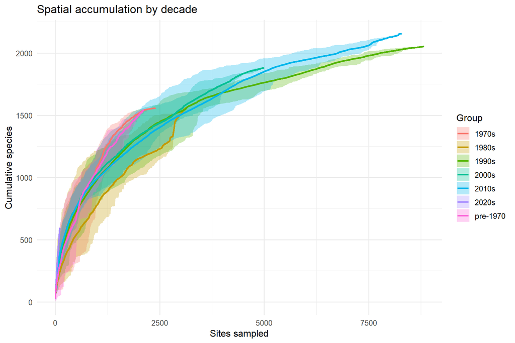

```r
plot(decade_combined) + ggtitle("Spatial accumulation by decade")
```

# 3. Native vs Alien (per decade)

Same spatial walks, different species tallies. Using the `groups` argument for efficiency.

```r
status_vec <- species[match(colnames(all_mat), WFO_TAXON), STATUS]

rds_decade_na <- file.path(comp_dir, "decade_na_results.rds")
if (file.exists(rds_decade_na)) {
  cat("Loading cached decade native/alien results...\n")
  decade_na_results <- readRDS(rds_decade_na)
} else {
  decade_na_results <- lapply(decades, function(d) {
    idx <- which(header$decade == d)
    n <- length(idx)
    spacc(all_mat[idx, , drop = FALSE], coords[idx, ],
          n_seeds = min(100, n), method = "knn",
          distance = "haversine", groups = status_vec, seed = 42)
  })
  names(decade_na_results) <- decades
  saveRDS(decade_na_results, rds_decade_na)
}
```

```
## Loading cached decade native/alien results...
```

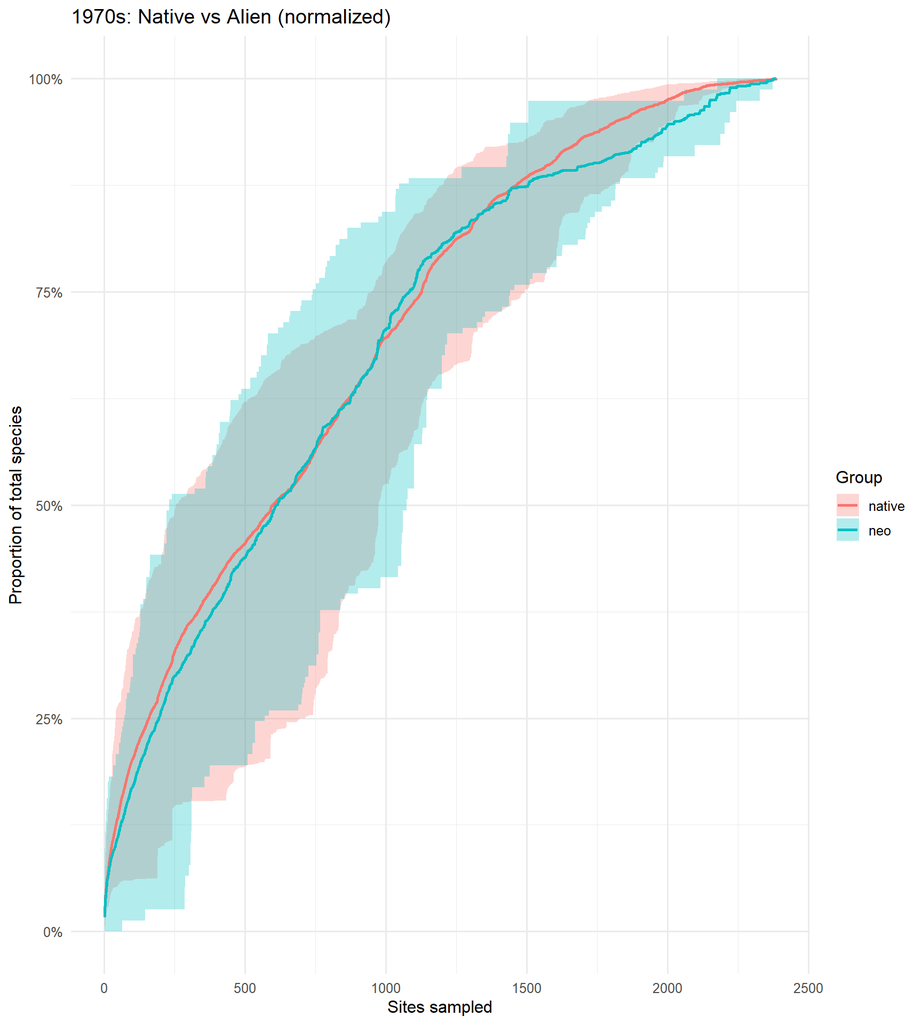

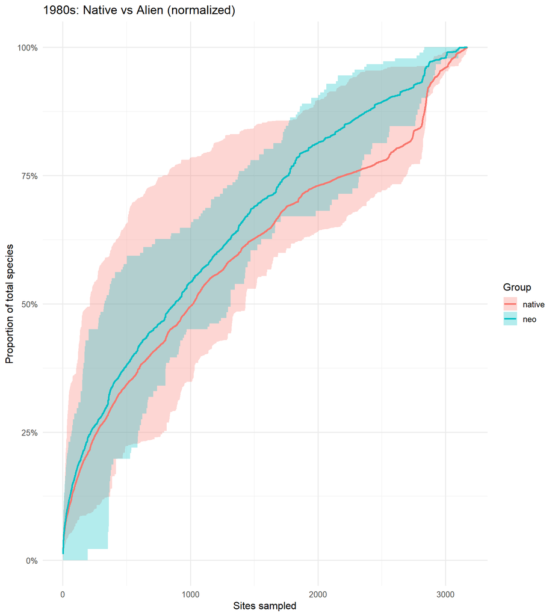

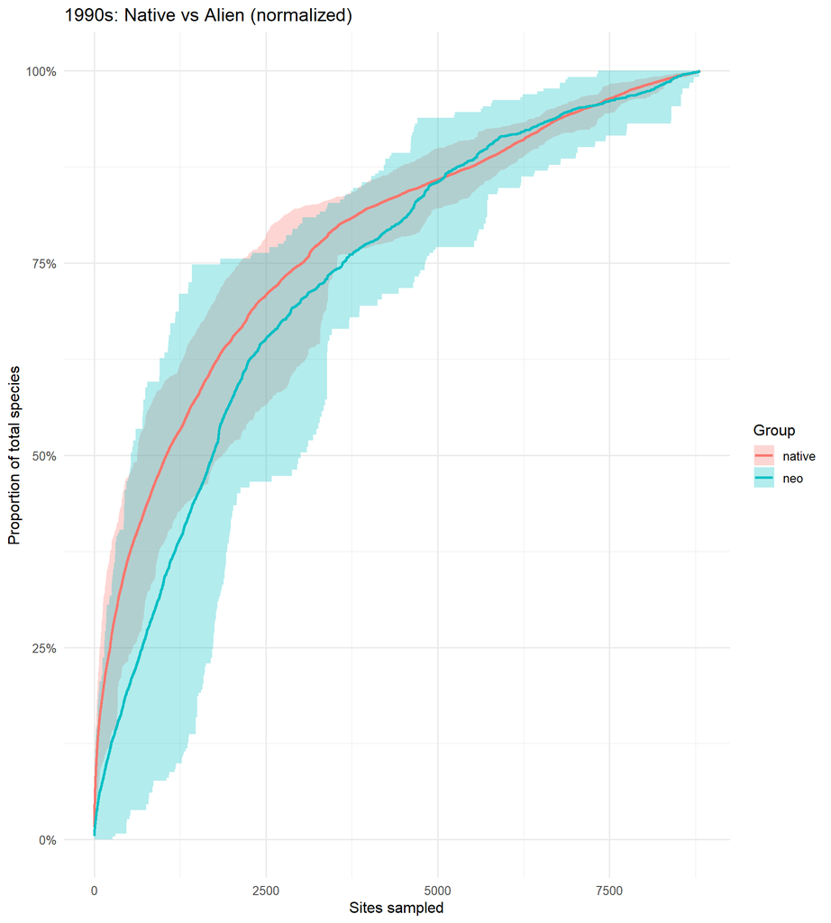

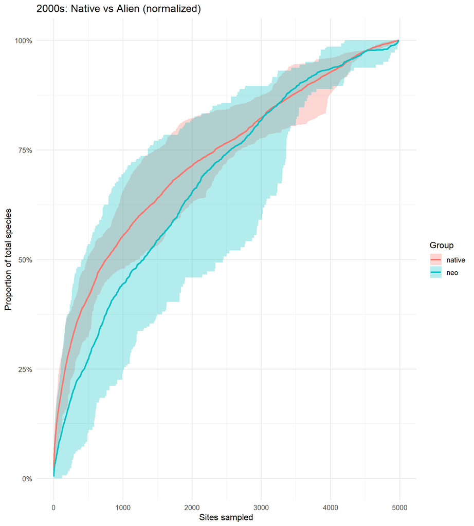

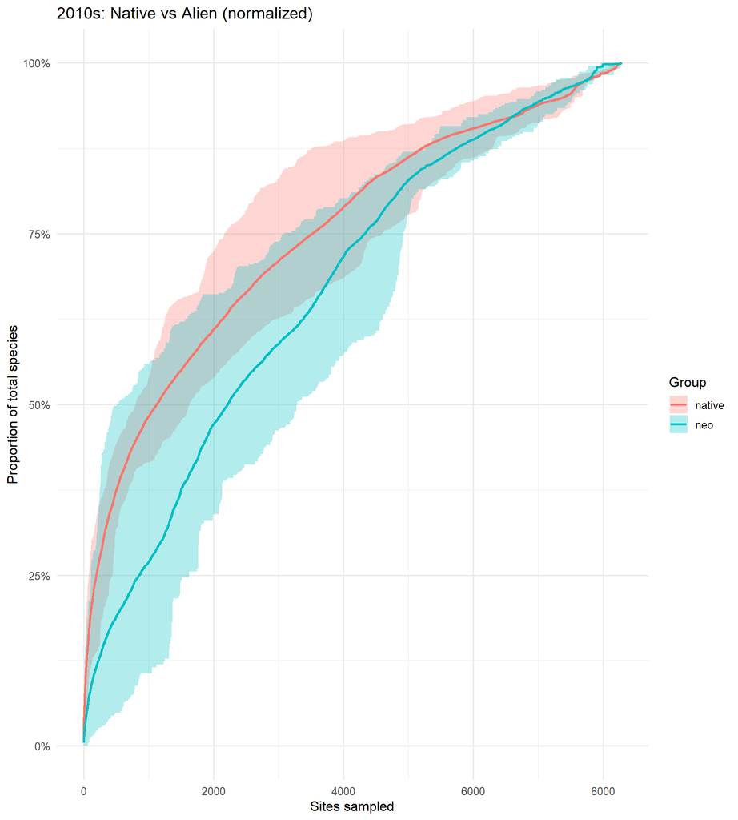

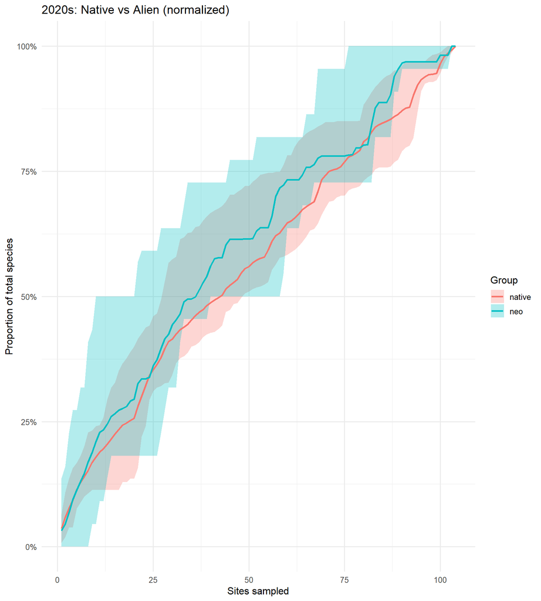

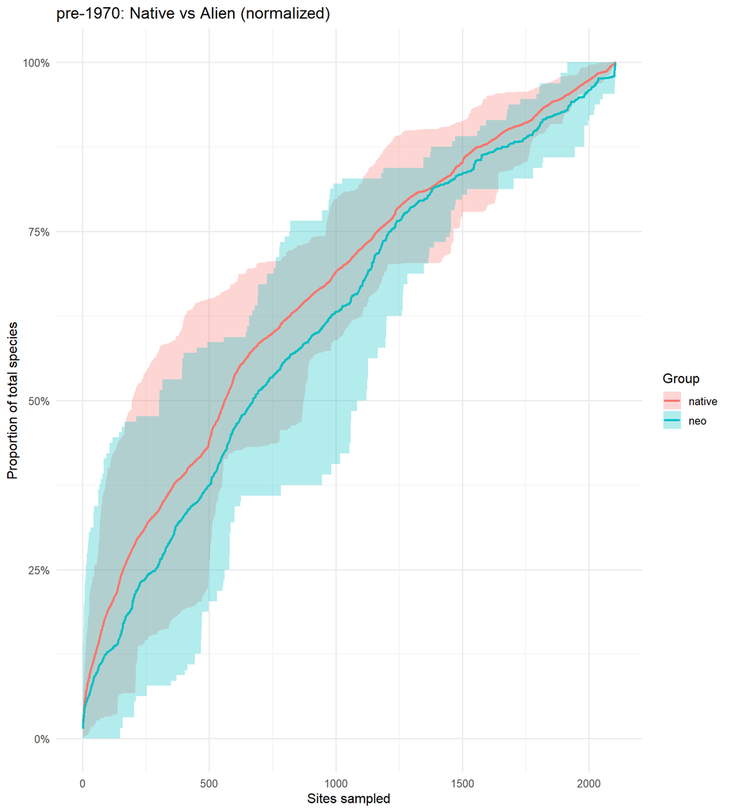

```r
for (d in decades) {
  print(plot_grouped_normalized(decade_na_results[[d]],
          title = sprintf("%s: Native vs Alien (normalized)", d)))
}
```

# 4. Pooled Analysis (all decades combined)

For overall comparisons we use the full dataset with moderate seed counts.

```r
rds_pooled <- file.path(comp_dir, "pooled.rds")
if (file.exists(rds_pooled)) {
  cat("Loading cached pooled results...\n")
  p <- readRDS(rds_pooled)
  sac_native <- p$native; sac_alien <- p$alien; sac_all <- p$all
  rm(p)
} else {
  sac_native <- spacc(native_mat, coords, n_seeds = 30, method = "knn",
                      distance = "haversine", seed = 42)
  sac_alien  <- spacc(alien_mat,  coords, n_seeds = 30, method = "knn",
                      distance = "haversine", seed = 42)
  sac_all    <- spacc(all_mat,    coords, n_seeds = 30, method = "knn",
                      distance = "haversine", seed = 42)
  saveRDS(list(native = sac_native, alien = sac_alien, all = sac_all), rds_pooled)
}
```

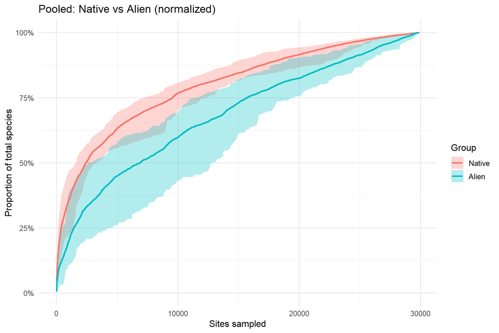

```r
plot_normalized(Native = sac_native, Alien = sac_alien,
                title = "Pooled: Native vs Alien (normalized)")
```

## Compare native vs alien statistically

```r
rds_compare <- file.path(comp_dir, "compare.rds")
if (file.exists(rds_compare)) {
  comp <- readRDS(rds_compare)
} else {
  comp <- compare(sac_native, sac_alien, method = "permutation", n_perm = 999)
  saveRDS(comp, rds_compare)
}
print(comp)
```

```
## Comparison: sac_native vs sac_alien
## ----------------------------------------
## Method: permutation (n=999)
## AUC difference: 50036933.1 (p = 0.000***)
## Saturation: sac_native at 18661 sites, sac_alien at 24060 sites
##
## sac_native saturates faster.
```

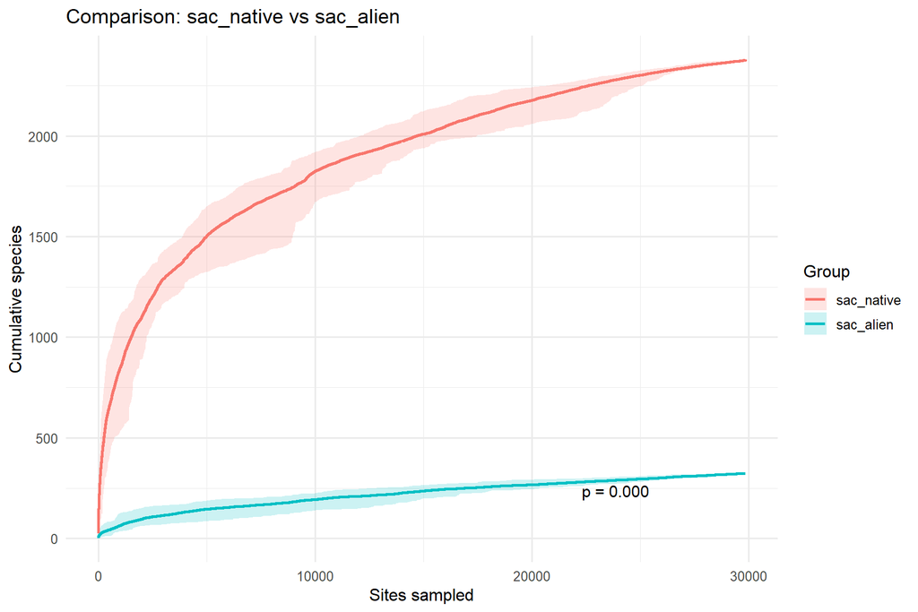

```r
plot(comp)
```

# 5. Extrapolation

Fit asymptotic models to estimate total richness for each group.

```r
rds_extrap <- file.path(comp_dir, "extrapolate.rds")
if (file.exists(rds_extrap)) {
  e <- readRDS(rds_extrap)
  fit_native <- e$native; fit_alien <- e$alien
  rm(e)
} else {
  fit_native <- extrapolate(sac_native, model = "lomolino")
  fit_alien  <- extrapolate(sac_alien,  model = "lomolino")
  saveRDS(list(native = fit_native, alien = fit_alien), rds_extrap)
}

cat("Native:\n"); print(fit_native)
```

```
## Native:
```

```
## Extrapolation: lomolino
## ------------------------------
## Estimated asymptote: 4733.1 species
## 95% CI: 4722.0 - 4744.2
## AIC: 223273.5
## Observed: 2378.0 species (50% of estimated)
```

```r
cat("\nAlien:\n");  print(fit_alien)
```

```
##
## Alien:
```

```
## Extrapolation: lomolino
## ------------------------------
## Model fitting failed
```

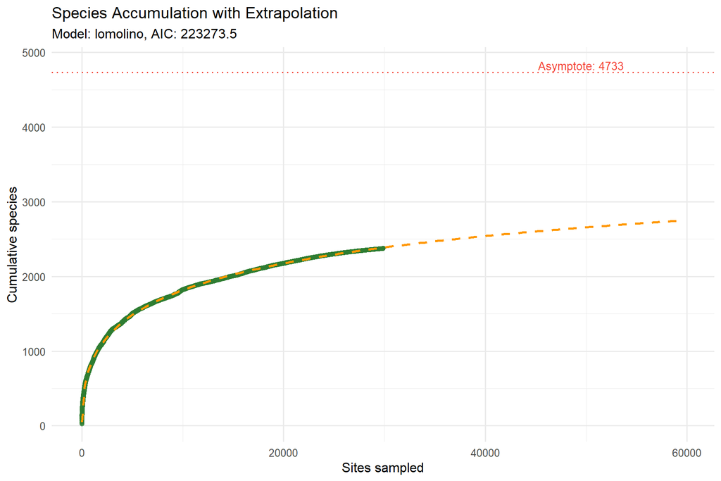

```r
plot(fit_native)
```

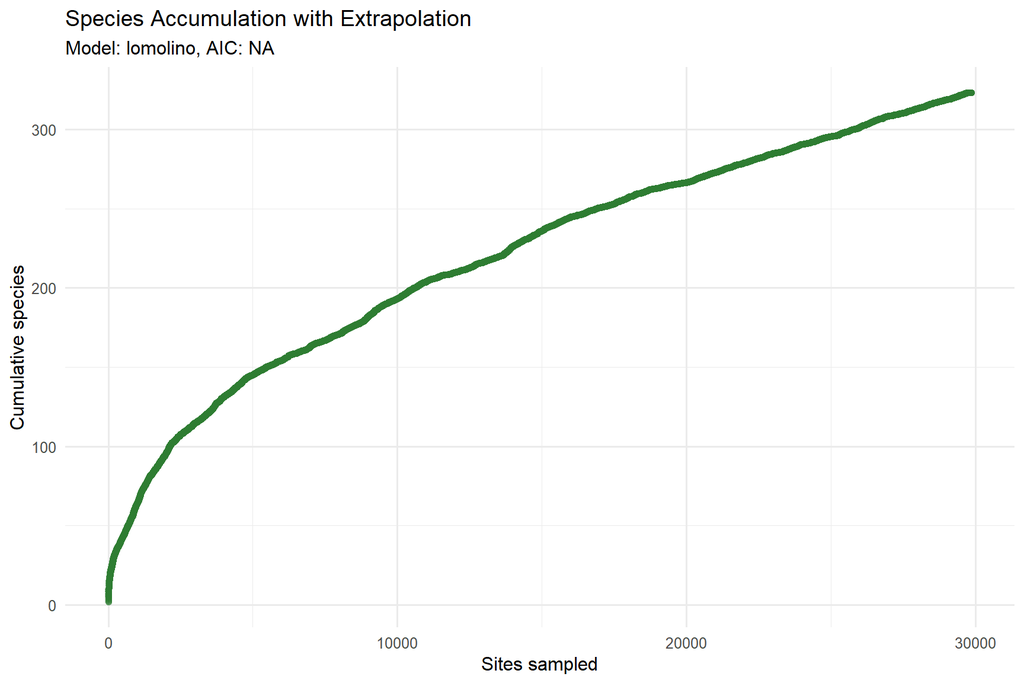

```r
plot(fit_alien)
```

# 6. Methods Comparison

Compare kNN (spatially structured) vs random (null model) accumulation. We use the 1990s decade (largest chunk) for speed.

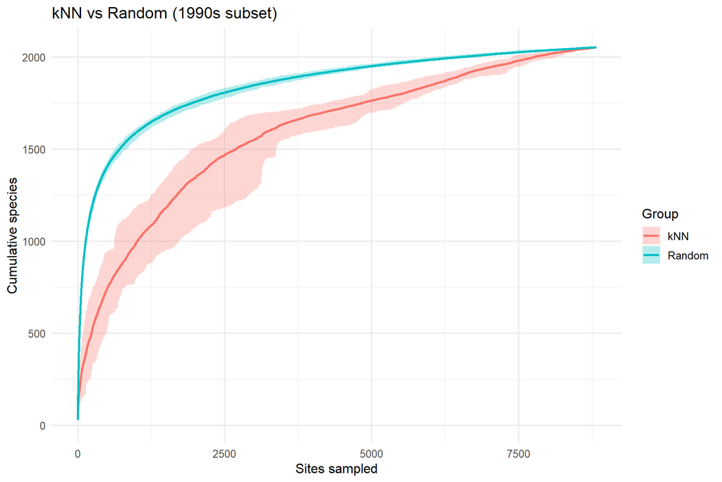

```r
idx_90s <- which(header$decade == "1990s")

rds_methods <- file.path(comp_dir, "methods_comparison.rds")
if (file.exists(rds_methods)) {
  m <- readRDS(rds_methods)
  sac_knn_m <- m$knn; sac_random_m <- m$random
  rm(m)
} else {
  sac_knn_m    <- spacc(all_mat[idx_90s, , drop = FALSE], coords[idx_90s, ],
                        method = "knn",    n_seeds = 50,
                        distance = "haversine", seed = 42)
  sac_random_m <- spacc(all_mat[idx_90s, , drop = FALSE], coords[idx_90s, ],
                        method = "random", n_seeds = 50,
                        distance = "haversine", seed = 42)
  saveRDS(list(knn = sac_knn_m, random = sac_random_m), rds_methods)
}

methods_combined <- c(kNN = sac_knn_m, Random = sac_random_m)
plot(methods_combined) + ggtitle("kNN vs Random (1990s subset)")
```

# 7. Hill Numbers

Track effective species diversity (q = 0, 1, 2) as sites accumulate. Using 1990s decade.

```r
rds_hill <- file.path(comp_dir, "hill.rds")
if (file.exists(rds_hill)) {
  hill <- readRDS(rds_hill)
} else {
  hill <- spaccHill(all_mat[idx_90s, , drop = FALSE], coords[idx_90s, ],
                    q = c(0, 1, 2), n_seeds = 30,
                    method = "knn", distance = "haversine", seed = 42)
  saveRDS(hill, rds_hill)
}
print(hill)
```

```
## spacc Hill numbers: 8814 sites, 2700 species, 30 seeds
## Orders (q): 0, 1, 2
## Method: knn
```

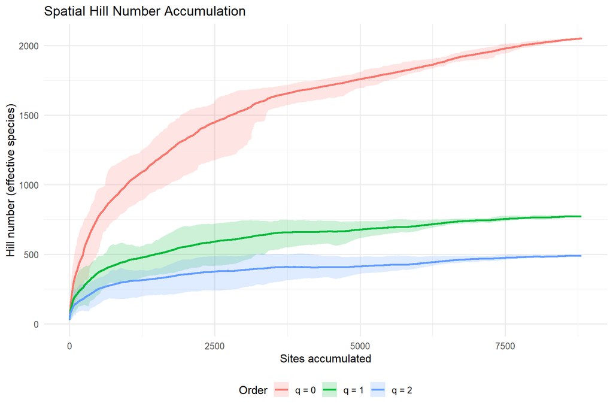

```r
plot(hill)
```

# 8. Beta Diversity Accumulation

Track how turnover and nestedness change as the sampling window expands.

```r
rds_beta <- file.path(comp_dir, "beta.rds")
if (file.exists(rds_beta)) {
  beta <- readRDS(rds_beta)
} else {
  beta <- spaccBeta(all_mat[idx_90s, , drop = FALSE], coords[idx_90s, ],
                    n_seeds = 30, index = "sorensen",
                    distance = "haversine", seed = 42)
  saveRDS(beta, rds_beta)
}
print(beta)
```

```
## spacc beta diversity: 8814 sites, 30 seeds
## Index: sorensen, Method: knn
## Mean final beta: 0.976 (turnover: 0.000, nestedness: 0.976)
```

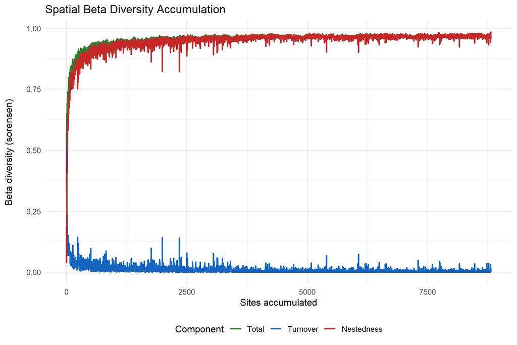

```r
plot(beta)
```

# 9. Coverage-Based Rarefaction

How many sites do we need for 90%, 95%, 99% completeness?

```r
rds_cov <- file.path(comp_dir, "coverage.rds")
if (file.exists(rds_cov)) {
  cov <- readRDS(rds_cov)
} else {
  cov <- spaccCoverage(all_mat[idx_90s, , drop = FALSE], coords[idx_90s, ],
                       n_seeds = 30,
                       distance = "haversine", seed = 42)
  saveRDS(cov, rds_cov)
}
print(cov)
```

```
## spacc coverage: 8814 sites, 2700 species, 30 seeds
## Mean final coverage: 99.9%
## Mean final richness: 2053.0 species
```

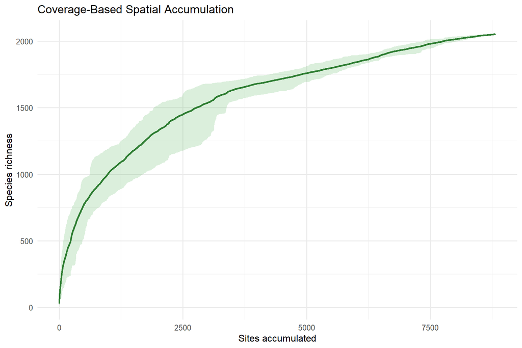

```r
plot(cov)
```

```r
# Interpolate to standard coverage targets
interp <- interpolateCoverage(cov, target = c(0.90, 0.95, 0.99))
cat("\nSites needed for target coverage:\n")
```

```
##
## Sites needed for target coverage:
```

```r
print(round(colMeans(interp, na.rm = TRUE), 1))
```

```
##   C90   C95   C99
## 134.1 192.9 463.1
```

# 10. Per-Site Metrics & Spatial Map

Compute accumulation metrics for every site as a starting point. Using 1990s subset.

```r
rds_metrics <- file.path(comp_dir, "metrics.rds")
if (file.exists(rds_metrics)) {
  metrics <- readRDS(rds_metrics)
} else {
  metrics <- spaccMetrics(all_mat[idx_90s, , drop = FALSE], coords[idx_90s, ],
                          metrics = c("slope_10", "half_richness", "auc"),
                          method = "knn", distance = "haversine")
  saveRDS(metrics, rds_metrics)
}
print(metrics)
```

```
## spacc_metrics: 8814 sites, 2700 species
## Method: knn
## Metrics: slope_10, half_richness, auc
```

```r
summary(metrics)
```

```
## Metric summary:
##   slope_10: mean=0.82, sd=0.17, range=[0.47, 1.23]
##   half_richness: mean=2050.14, sd=486.35, range=[1204.00, 3454.00]
##   auc: mean=1585.70, sd=38.80, range=[1503.78, 1658.52]
```

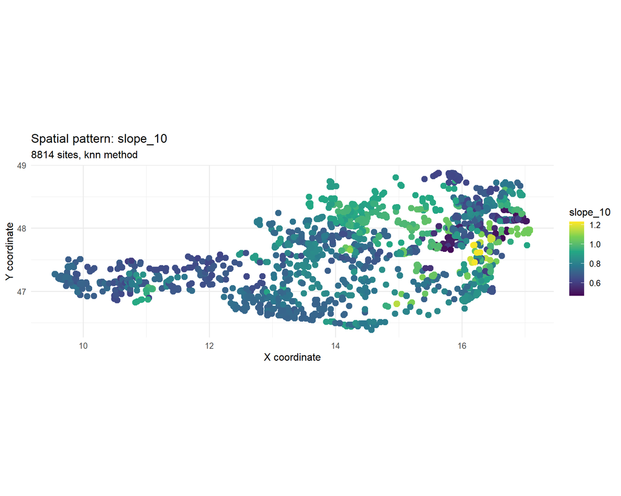

```r
plot(metrics, type = "points")
```

# 11. Diversity Partitioning

Decompose regional diversity into alpha, beta, and gamma components.

```r
rds_part <- file.path(comp_dir, "partition.rds")
if (file.exists(rds_part)) {
  partition <- readRDS(rds_part)
} else {
  partition <- diversityPartition(all_mat[idx_90s, , drop = FALSE], q = c(0, 1, 2),
                                  coords = data.frame(x = coords$x[idx_90s], y = coords$y[idx_90s]))
  saveRDS(partition, rds_part)
}
print(partition)
```

```
## Alpha-Beta-Gamma Diversity Partitioning
## 8814 sites, 2700 species
##
##  q alpha  beta   gamma
##  0 30.54 67.22 2053.00
##  1 26.54 29.17  774.29
##  2 21.09 23.27  490.89
##
## Interpretation:
##   Alpha = mean effective species per site
##   Beta  = effective number of communities (1 to n_sites)
##   Gamma = regional effective species (gamma = alpha x beta)
```

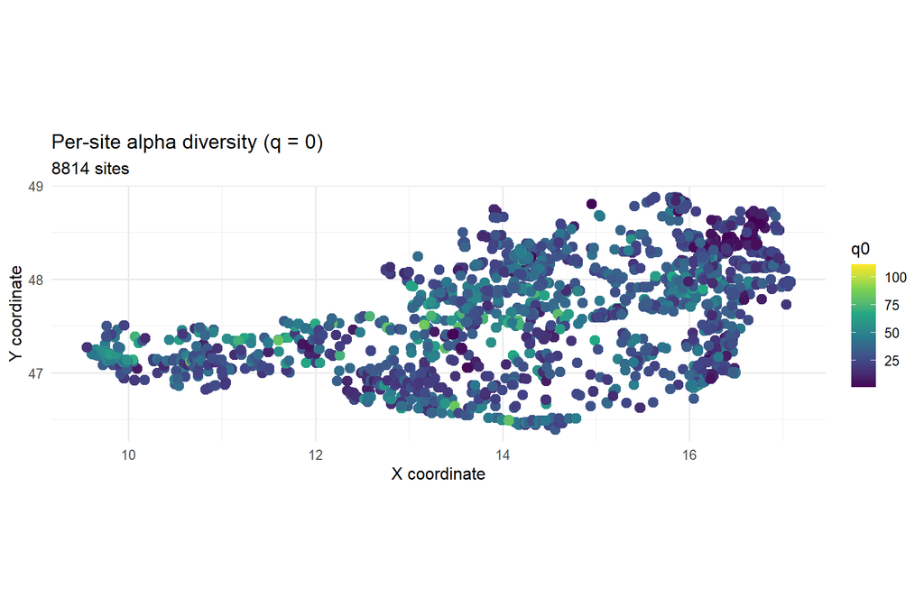

```r
plot(partition)
```

## Alpha diversity per site

```r
rds_alpha <- file.path(comp_dir, "alpha.rds")
if (file.exists(rds_alpha)) {
  alpha <- readRDS(rds_alpha)
} else {
  alpha <- alphaDiversity(all_mat[idx_90s, , drop = FALSE], q = c(0, 1, 2),
                          coords = data.frame(x = coords$x[idx_90s], y = coords$y[idx_90s]))
  saveRDS(alpha, rds_alpha)
}
print(alpha)
```

```
## spacc alpha diversity: 8814 sites, 2700 species
## Orders (q): 0, 1, 2
## Coordinates: available
```

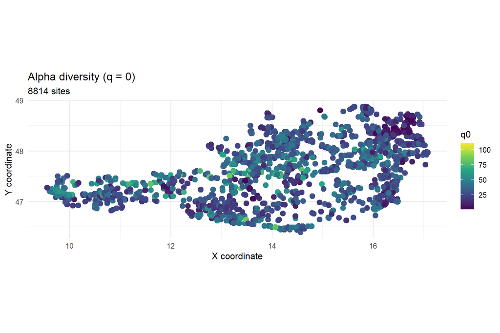

```r
plot(alpha)
```

# 12. Analytical Benchmarks

Compare simulation-based curves to exact analytical expectations. Using 1990s subset.

```r
cole <- coleman(all_mat[idx_90s, , drop = FALSE])
mt   <- mao_tau(all_mat[idx_90s, , drop = FALSE])

plot(sac_knn_m)
# Overlay analytical curves for comparison
```

[output not shown]

# 13. Grouped Accumulation by Status

Use the `groups` argument to run a single accumulation with automatic native/alien splitting. Using 1990s subset.

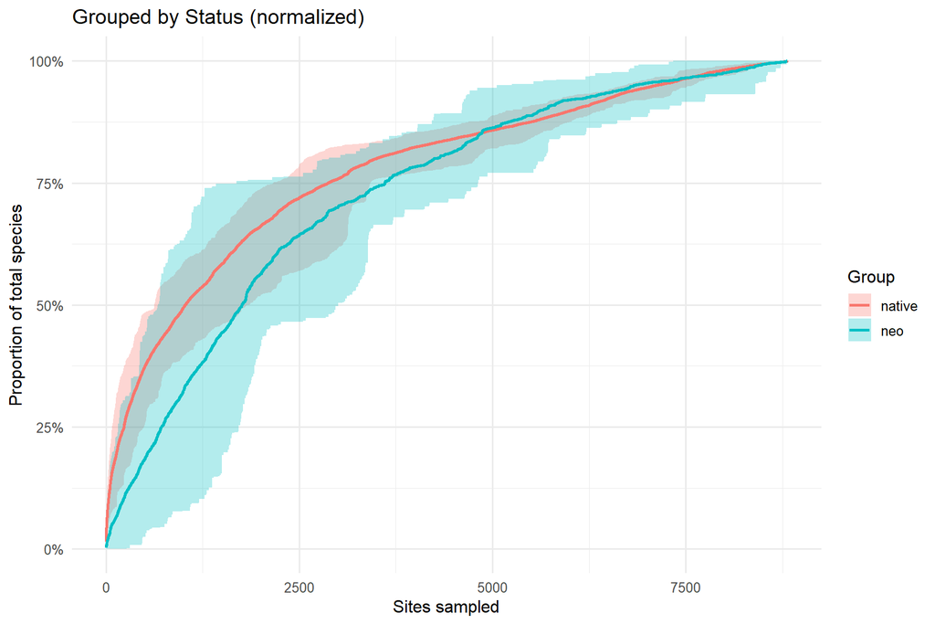

```r
rds_grouped <- file.path(comp_dir, "grouped_status.rds")
if (file.exists(rds_grouped)) {
  sac_grouped <- readRDS(rds_grouped)
} else {
  sac_grouped <- spacc(all_mat[idx_90s, , drop = FALSE], coords[idx_90s, ],
                       n_seeds = 50, method = "knn",
                       distance = "haversine", groups = status_vec, seed = 42)
  saveRDS(sac_grouped, rds_grouped)
}
plot_grouped_normalized(sac_grouped,
                        title = "Grouped by Status (normalized)")
```

# 14. Habitat-Level Analysis (EUNIS)

Compare accumulation curves across broad habitat types (EUNIS level 1). We subset to habitats with at least 100 plots.

```r
habitat <- header$Eunis_lvl1

hab_counts <- table(habitat)
keep_habs  <- names(hab_counts[hab_counts >= 100])
keep_habs  <- keep_habs[!keep_habs %in% c("", "~")]  # drop junk codes
cat(sprintf("Habitats with >= 100 plots: %s\n", paste(keep_habs, collapse = ", ")))
```

```
## Habitats with >= 100 plots: P, Q, R, S, T, U, V
```

```r
cat("Plot counts:\n")
```

```
## Plot counts:
```

```r
print(hab_counts[keep_habs])
```

```
## habitat
##     P     Q     R     S     T     U     V
##   223  1102 14193  1109  7001   327  4642
```

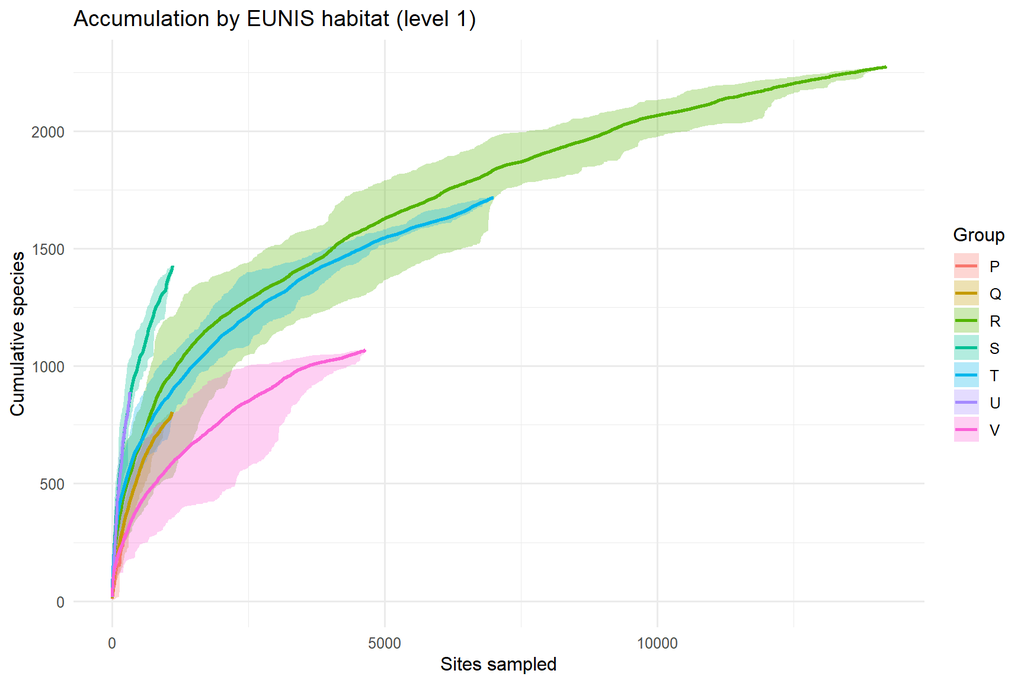

```r
rds_hab <- file.path(comp_dir, "habitat_curves.rds")
if (file.exists(rds_hab)) {
  hab_results <- readRDS(rds_hab)
} else {
  hab_results <- lapply(keep_habs, function(h) {
    idx <- which(habitat == h)
    spacc(all_mat[idx, , drop = FALSE],
          coords[idx, ],
          n_seeds = 50, method = "knn",
          distance = "haversine", seed = 42)
  })
  names(hab_results) <- keep_habs
  saveRDS(hab_results, rds_hab)
}
hab_combined <- do.call(c, hab_results)
plot(hab_combined) + ggtitle("Accumulation by EUNIS habitat (level 1)")
```

## Native vs alien within habitats

Are aliens more concentrated in certain habitats?

```r
hab_alien <- header[, .(PlotObservationID, Eunis_lvl1)]
hab_alien <- merge(hab_alien,
                   species[, .(n_native = sum(STATUS == "native"),
                               n_alien  = sum(STATUS == "neo")),
                           by = PlotObservationID],
                   by = "PlotObservationID")
hab_summary <- hab_alien[Eunis_lvl1 %in% keep_habs,
                         .(mean_native = mean(n_native),
                           mean_alien  = mean(n_alien),
                           alien_pct   = mean(n_alien / (n_native + n_alien)) * 100),
                         by = Eunis_lvl1]
print(hab_summary[order(-alien_pct)])
```

```
##    Eunis_lvl1 mean_native mean_alien  alien_pct
##        <char>       <num>      <num>      <num>
## 1:          V   18.189573 2.65812150 14.7518372
## 2:          U   15.547401 0.57186544  2.7899982
## 3:          Q   11.684211 0.25045372  2.1949699
## 4:          T   34.986288 0.65119269  1.9088159
## 5:          R   29.732403 0.50806736  1.8607575
## 6:          S   26.117223 0.23805230  0.9541968
## 7:          P    5.834081 0.01793722  0.1002564
```

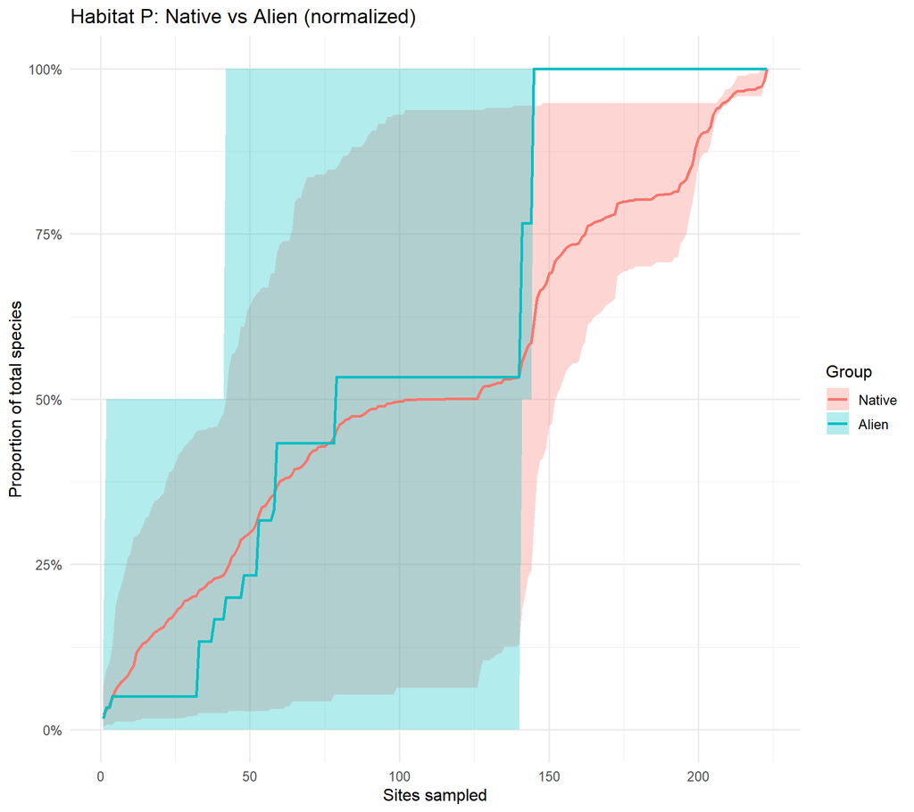

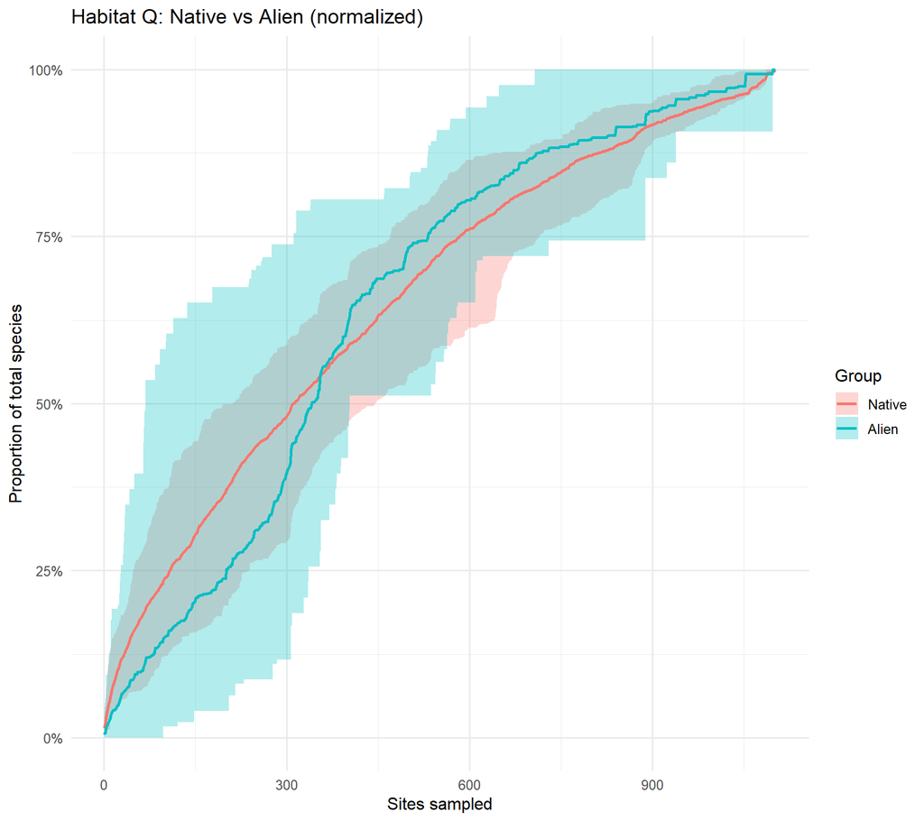

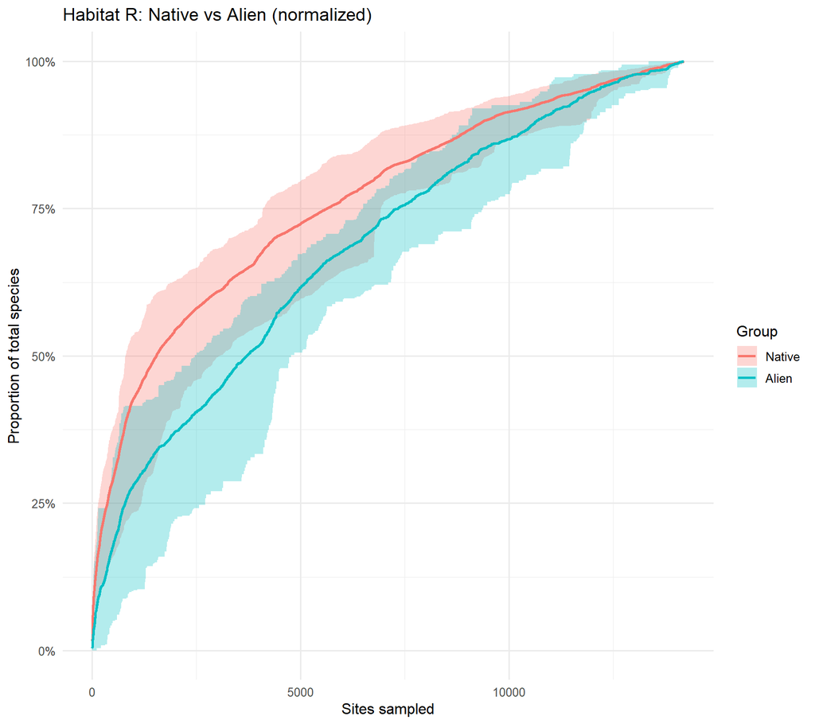

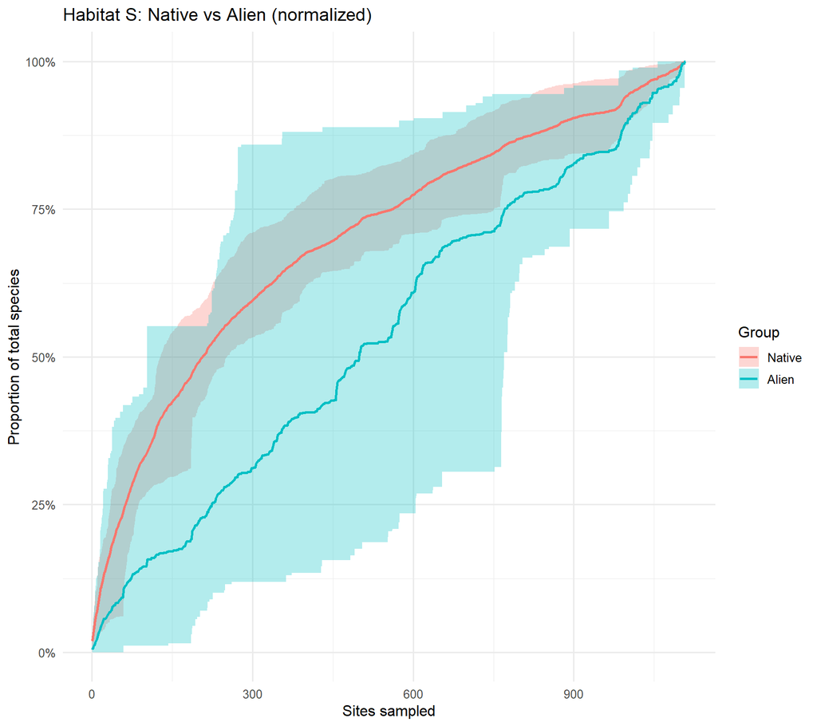

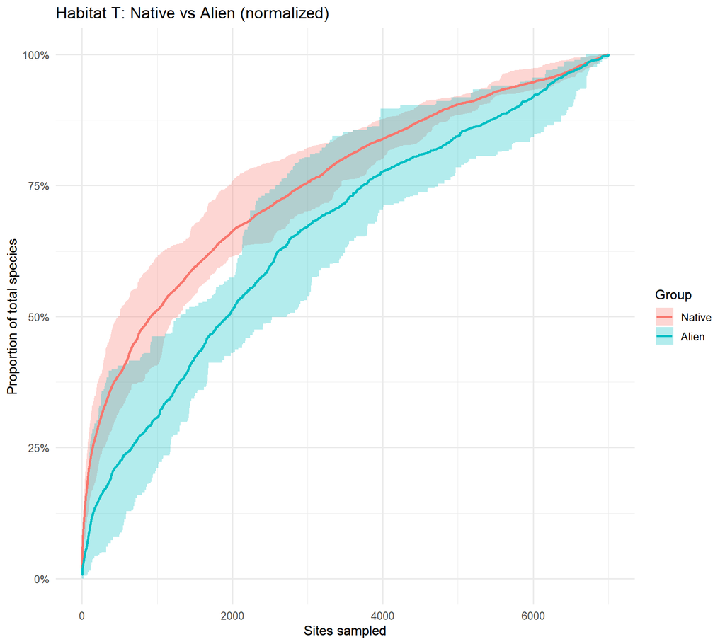

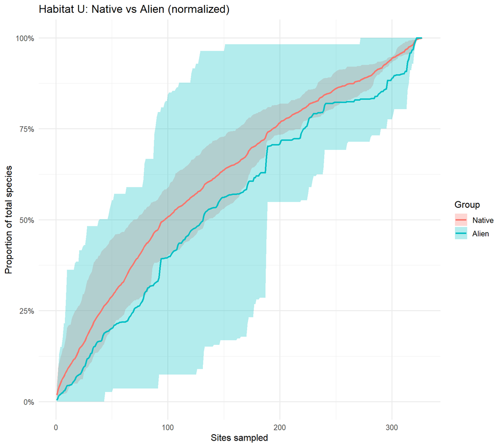

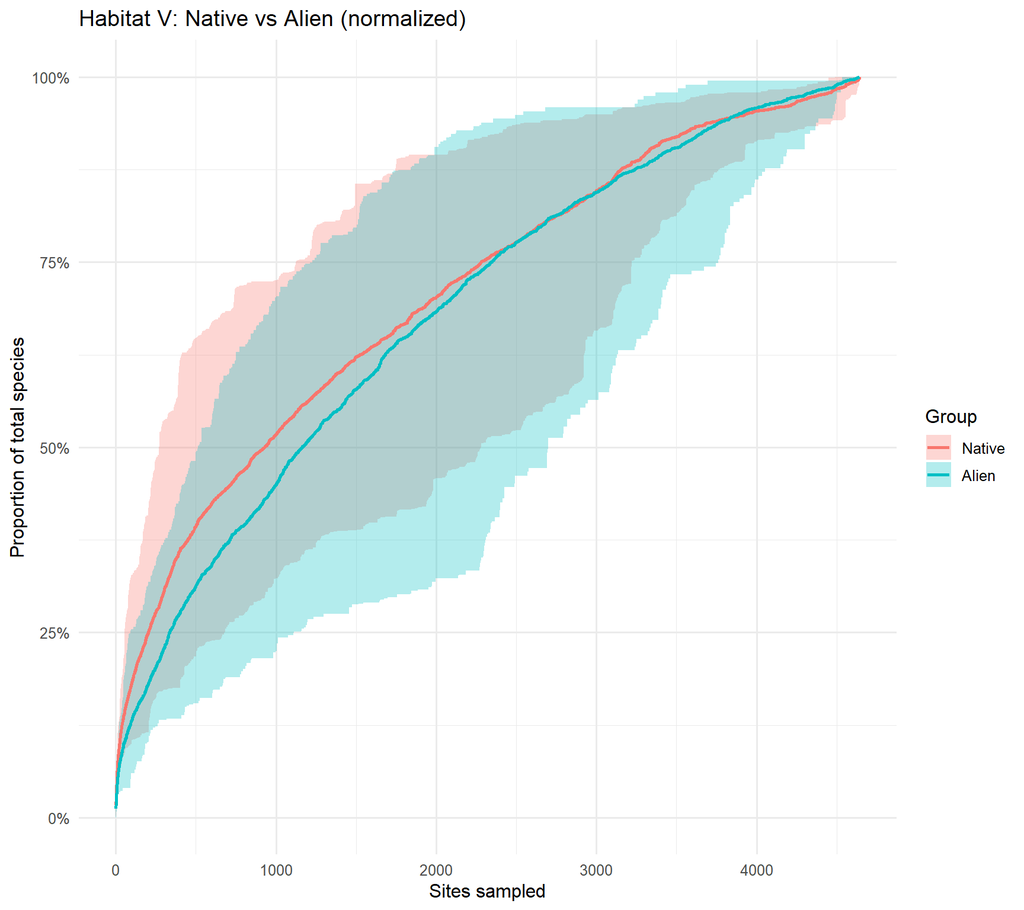

```r
rds_hab_na <- file.path(comp_dir, "habitat_native_alien.rds")
if (file.exists(rds_hab_na)) {
  hab_na_results <- readRDS(rds_hab_na)
} else {
  hab_na_results <- lapply(keep_habs, function(h) {
    nm <- native_mat[which(habitat == h), , drop = FALSE]
    am <- alien_mat[which(habitat == h), , drop = FALSE]
    nm <- nm[, colSums(nm) > 0, drop = FALSE]
    am <- am[, colSums(am) > 0, drop = FALSE]
    if (ncol(nm) < 2 || ncol(am) < 2 || nrow(nm) < 3) return(NULL)
    idx <- which(habitat == h)
    list(
      native = spacc(nm, coords[idx, ],
                     n_seeds = 30, method = "knn",
                     distance = "haversine", seed = 42),
      alien  = spacc(am, coords[idx, ],
                     n_seeds = 30, method = "knn",
                     distance = "haversine", seed = 42)
    )
  })
  names(hab_na_results) <- keep_habs
  saveRDS(hab_na_results, rds_hab_na)
}

for (h in keep_habs) {
  if (is.null(hab_na_results[[h]])) next
  print(plot_normalized(Native = hab_na_results[[h]]$native,
                        Alien  = hab_na_results[[h]]$alien,
                        title = sprintf("Habitat %s: Native vs Alien (normalized)", h)))
}
```

# 15. Phylogenetic Diversity Accumulation

Track phylogenetic diversity (MPD, MNTD) as the sampling window expands spatially. Using 1990s subset for speed.

```r
library(ape)
tree_cache <- file.path(data_path, "phylo_tree.rds")

if (file.exists(tree_cache)) {
  cat("Loading cached phylogeny...\n")
  tree <- readRDS(tree_cache)
  run_phylo <- TRUE
} else if (!requireNamespace("V.PhyloMaker2", quietly = TRUE)) {
  cat("V.PhyloMaker2 not installed and no cached tree found - skipping.\n",
      "Install with: remotes::install_github('jinyizju/V.PhyloMaker2')\n")
  run_phylo <- FALSE
} else {
  run_phylo <- TRUE
  library(V.PhyloMaker2)

  sp_lookup <- unique(species[, .(species = WFO_TAXON, family = WFO_FAMILY)])
  sp_lookup[, genus := sub(" .*", "", species)]

  cat(sprintf("Placing %d species on mega-tree (first run, will cache)...\n",
              nrow(sp_lookup)))
  phylo_result <- phylo.maker(
    sp.list = as.data.frame(sp_lookup[, .(species, genus, family)]),
    scenarios = "S3"
  )
  tree <- phylo_result$scenario.3
  tree$tip.label <- gsub("_", " ", tree$tip.label)

  saveRDS(tree, tree_cache)
  cat(sprintf("Tree saved to %s\n", tree_cache))
}
```

```
## Loading cached phylogeny...
```

```r
if (run_phylo) {
  # Reload matrices for subsetting (freed above)
  mats <- readRDS(file.path(comp_dir, "matrices.rds"))
  all_mat_phylo <- mats$all; native_mat_phylo <- mats$native; alien_mat_phylo <- mats$alien
  rm(mats); invisible(gc())

  in_tree <- colnames(all_mat_phylo) %in% tree$tip.label
  cat(sprintf("Species matched to tree: %d / %d (%.0f%%)\n",
              sum(in_tree), ncol(all_mat_phylo), mean(in_tree) * 100))

  phylo_mat <- all_mat_phylo[idx_90s, in_tree, drop = FALSE]
  tree <- keep.tip(tree, colnames(all_mat_phylo)[in_tree])
}
```

```
## Species matched to tree: 2697 / 2700 (100%)
```

```
## spacc phylogenetic diversity: 8814 sites, 2697 species, 30 seeds
## Metrics: mpd, mntd
```

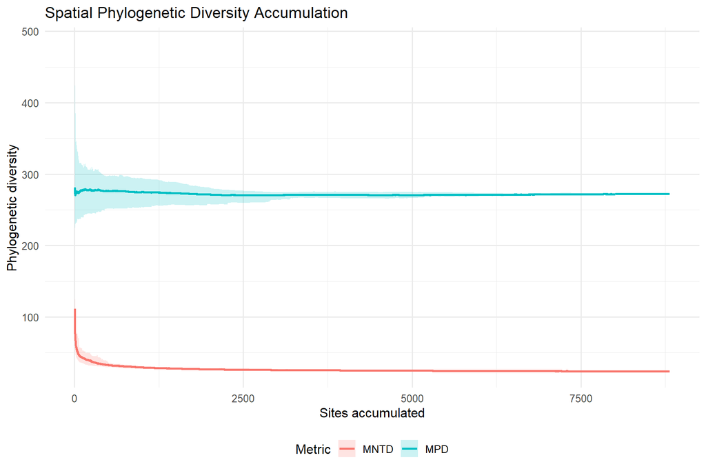

```r
if (run_phylo) {
  rds_phylo <- file.path(comp_dir, "phylo_sac.rds")
  if (file.exists(rds_phylo)) {
    phylo_sac <- readRDS(rds_phylo)
  } else {
    phylo_sac <- spaccPhylo(phylo_mat, coords[idx_90s, ], tree = tree,
                             metric = c("mpd", "mntd"),
                             n_seeds = 30, method = "knn",
                             distance = "haversine", seed = 42)
    saveRDS(phylo_sac, rds_phylo)
  }
  print(phylo_sac)
  plot(phylo_sac)
}
```

## Phylogenetic diversity: native vs alien

```r
if (run_phylo) {
  rds_phylo_na <- file.path(comp_dir, "phylo_native_alien.rds")
  if (file.exists(rds_phylo_na)) {
    pna <- readRDS(rds_phylo_na)
    phylo_native <- pna$native; phylo_alien <- pna$alien
    rm(pna)
  } else {
    native_in_tree <- colnames(native_mat_phylo) %in% tree$tip.label
    alien_in_tree  <- colnames(alien_mat_phylo) %in% tree$tip.label

    phylo_native <- spaccPhylo(native_mat_phylo[idx_90s, native_in_tree, drop = FALSE],
                                coords[idx_90s, ], tree = tree, metric = "mpd",
                                n_seeds = 30, method = "knn",
                                distance = "haversine", seed = 42)
    phylo_alien  <- spaccPhylo(alien_mat_phylo[idx_90s, alien_in_tree, drop = FALSE],
                                coords[idx_90s, ], tree = tree, metric = "mpd",
                                n_seeds = 30, method = "knn",
                                distance = "haversine", seed = 42)
    saveRDS(list(native = phylo_native, alien = phylo_alien), rds_phylo_na)
  }

  cat("Native MPD accumulation:\n"); print(phylo_native)
  cat("\nAlien MPD accumulation:\n"); print(phylo_alien)
}
```

```
## Native MPD accumulation:
## spacc phylogenetic diversity: 8814 sites, 2375 species, 30 seeds
## Metrics: mpd
##
## Alien MPD accumulation:
## spacc phylogenetic diversity: 8814 sites, 322 species, 30 seeds
## Metrics: mpd
```

# 16. Functional Diversity Accumulation

Track functional diversity (FDis) as sites accumulate. Using family + status as proxy traits. Using 1990s subset.

```r
if (!requireNamespace("FD", quietly = TRUE)) {
  cat("FD package not installed - skipping functional analysis.\n",
      "Install with: install.packages('FD')\n")
  run_func <- FALSE
} else {
  run_func <- TRUE

  # Reload all_mat for subsetting
  mats <- readRDS(file.path(comp_dir, "matrices.rds"))
  all_mat_func <- mats$all
  rm(mats); invisible(gc())

  sp_info <- unique(species[, .(species = WFO_TAXON, family = WFO_FAMILY,
                                 status = STATUS)])
  sp_info <- sp_info[species %in% colnames(all_mat_func)]
  sp_info <- sp_info[!duplicated(species)]
  setkey(sp_info, species)

  trait_df <- data.frame(
    family = as.factor(sp_info$family),
    status = as.factor(sp_info$status),
    row.names = sp_info$species
  )

  shared_sp <- intersect(colnames(all_mat_func), rownames(trait_df))
  func_mat  <- all_mat_func[idx_90s, shared_sp, drop = FALSE]
  trait_df  <- trait_df[shared_sp, , drop = FALSE]

  # Convert factors to numeric dummy variables for distance computation
  trait_mat <- model.matrix(~ family + status - 1, data = trait_df)
  rownames(trait_mat) <- rownames(trait_df)

  cat(sprintf("Functional analysis: %d species with traits, %d sites\n",
              length(shared_sp), nrow(func_mat)))
  rm(all_mat_func); invisible(gc())
}
```

```
## Functional analysis: 2699 species with traits, 8814 sites
```

```
## spacc functional diversity: 8814 sites, 2699 species, 124 traits, 30 seeds
## Metrics: fdis
```

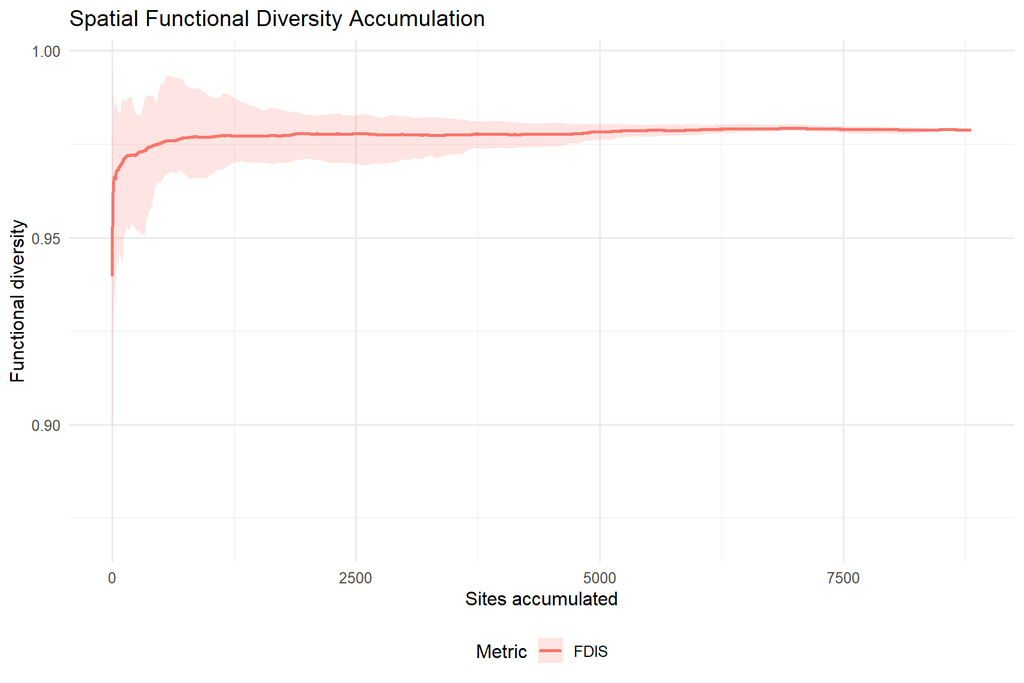

```r
if (run_func) {
  rds_func <- file.path(comp_dir, "func_sac.rds")
  if (file.exists(rds_func)) {
    func_sac <- readRDS(rds_func)
  } else {
    func_sac <- spaccFunc(func_mat, coords[idx_90s, ], traits = trait_mat,
                           metric = "fdis",
                           n_seeds = 30, method = "knn",
                           distance = "haversine", seed = 42)
    saveRDS(func_sac, rds_func)
  }
  print(func_sac)
  plot(func_sac)
}
```

# 17. Halo Analysis (Area of Effect)

Use the halo dataset (Austria + surrounding buffer) to see how edge effects influence accumulation.

```r
# Load areaOfEffect countries data (needed for support = "Austria")
data(countries, package = "areaOfEffect", envir = environment())

header_halo  <- fread(file.path(data_path, "austria_header_halo.csv"))
species_halo <- fread(file.path(data_path, "austria_species_halo.csv"))

cat(sprintf("Total plots: %d (core: %d, halo: %d)\n",
            nrow(header_halo),
            sum(header_halo$aoe_class == "core"),
            sum(header_halo$aoe_class == "halo")))
```

```
## Total plots: 116413 (core: 52546, halo: 63867)
```

```r
common_halo <- intersect(header_halo$PlotObservationID,
                         species_halo$PlotObservationID)
header_halo <- header_halo[PlotObservationID %in% common_halo]
coords_halo <- header_halo[, .(x = Longitude, y = Latitude)]
plot_ids_halo <- header_halo$PlotObservationID

halo_mat <- make_pa_matrix(species_halo[, .(PlotObservationID, WFO_TAXON)],
                           plot_ids_halo)
```

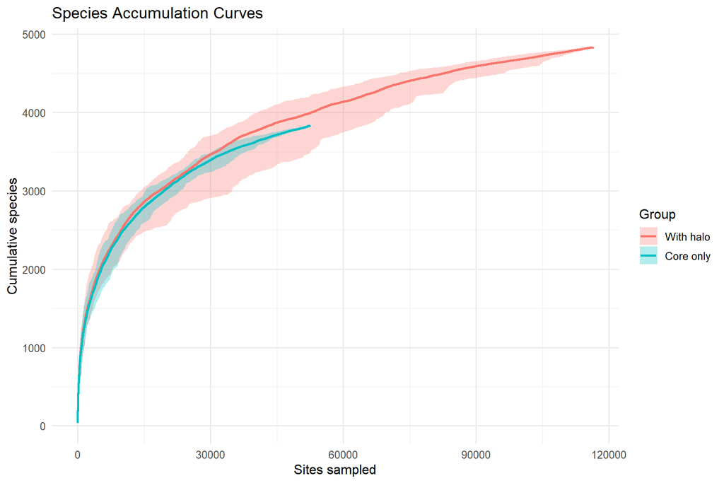

```r
rds_halo <- file.path(comp_dir, "halo.rds")
if (file.exists(rds_halo)) {
  h <- readRDS(rds_halo)
  sac_halo <- h$halo; sac_core <- h$core
  rm(h)
} else {
  sac_halo <- spacc(halo_mat, coords_halo, n_seeds = 30, method = "knn",
                    distance = "haversine", support = "Austria",
                    include_halo = TRUE, seed = 42)
  sac_core <- spacc(halo_mat, coords_halo, n_seeds = 30, method = "knn",
                    distance = "haversine", support = "Austria",
                    include_halo = FALSE, seed = 42)
  saveRDS(list(halo = sac_halo, core = sac_core), rds_halo)
}

halo_combined <- c(`With halo` = sac_halo, `Core only` = sac_core)
plot(halo_combined)
```